# White Wine Quality

Baskaran Viswanathan

October 12, 2015

## Abstract

Wine industry is a lucrative industry which is growing as social drining is on rise. There are many factors that make the taste and quality of wine unique. These factors are but now limited to the followings:

- acidity
- pH level
- sugar remained in wine
- chlorides

In this project we use a dataset of wines. In this dataset there are 4898 observations of White Wines that are produced in Portugal. Different properties of each wine is tested and collected for this dataset. Also, Each variety of wine is tasted by three independent tasters and the final rank assigned is the median rank given by the tasters.

I try to understand this dataset better and also try to find out if there is a relationship between quality of wine and different properties of it

The final result will be predictive model and patterns discovery of wine quality based on chemical properties.

In the first section presented data exploration. In the second part building predictive model.

## First Part Section

```
## [1] 4898   13
```

```
## 'data.frame':    4898 obs. of  13 variables:
##  $ X                   : int  1 2 3 4 5 6 7 8 9 10 ...
##  $ fixed.acidity       : num  7 6.3 8.1 7.2 7.2 8.1 6.2 7 6.3 8.1 ...
##  $ volatile.acidity    : num  0.27 0.3 0.28 0.23 0.23 0.28 0.32 0.27 0.3 0.22 ...
##  $ citric.acid         : num  0.36 0.34 0.4 0.32 0.32 0.4 0.16 0.36 0.34 0.43 ...
##  $ residual.sugar      : num  20.7 1.6 6.9 8.5 8.5 6.9 7 20.7 1.6 1.5 ...
##  $ chlorides           : num  0.045 0.049 0.05 0.058 0.058 0.05 0.045 0.045 0.049 0.044 ...
##  $ free.sulfur.dioxide : num  45 14 30 47 47 30 30 45 14 28 ...
##  $ total.sulfur.dioxide: num  170 132 97 186 186 97 136 170 132 129 ...
##  $ density             : num  1.001 0.994 0.995 0.996 0.996 ...
##  $ pH                  : num  3 3.3 3.26 3.19 3.19 3.26 3.18 3 3.3 3.22 ...
##  $ sulphates           : num  0.45 0.49 0.44 0.4 0.4 0.44 0.47 0.45 0.49 0.45 ...
##  $ alcohol             : num  8.8 9.5 10.1 9.9 9.9 10.1 9.6 8.8 9.5 11 ...
##  $ quality             : int  6 6 6 6 6 6 6 6 6 6 ...
```

```
##        X        fixed.acidity    volatile.acidity  citric.acid
##  Min.   :   1   Min.   : 3.800   Min.   :0.0800   Min.   :0.0000
##  1st Qu.:1225   1st Qu.: 6.300   1st Qu.:0.2100   1st Qu.:0.2700
##  Median :2450   Median : 6.800   Median :0.2600   Median :0.3200
##  Mean   :2450   Mean   : 6.855   Mean   :0.2782   Mean   :0.3342
##  3rd Qu.:3674   3rd Qu.: 7.300   3rd Qu.:0.3200   3rd Qu.:0.3900
##  Max.   :4898   Max.   :14.200   Max.   :1.1000   Max.   :1.6600
##  residual.sugar     chlorides       free.sulfur.dioxide
##  Min.   : 0.600   Min.   :0.00900   Min.   :  2.00
##  1st Qu.: 1.700   1st Qu.:0.03600   1st Qu.: 23.00
##  Median : 5.200   Median :0.04300   Median : 34.00
##  Mean   : 6.391   Mean   :0.04577   Mean   : 35.31
##  3rd Qu.: 9.900   3rd Qu.:0.05000   3rd Qu.: 46.00
##  Max.   :65.800   Max.   :0.34600   Max.   :289.00
##  total.sulfur.dioxide    density             pH          sulphates
##  Min.   :  9.0        Min.   :0.9871   Min.   :2.720   Min.   :0.2200
##  1st Qu.:108.0        1st Qu.:0.9917   1st Qu.:3.090   1st Qu.:0.4100
##  Median :134.0        Median :0.9937   Median :3.180   Median :0.4700
##  Mean   :138.4        Mean   :0.9940   Mean   :3.188   Mean   :0.4898
##  3rd Qu.:167.0        3rd Qu.:0.9961   3rd Qu.:3.280   3rd Qu.:0.5500
##  Max.   :440.0        Max.   :1.0390   Max.   :3.820   Max.   :1.0800
##     alcohol         quality
##  Min.   : 8.00   Min.   :3.000
##  1st Qu.: 9.50   1st Qu.:5.000
##  Median :10.40   Median :6.000
##  Mean   :10.51   Mean   :5.878
##  3rd Qu.:11.40   3rd Qu.:6.000
##  Max.   :14.20   Max.   :9.000
```

There are 4898 observations and 13 features. Input variables which includes 11 chemical features of white wine and output variable which is wine quality.

Below is brief description of each feature: Input variables (based on physicochemical tests):

Chemical Prperties:

- fixed acidity: most acids involved with wine or fixed or nonvolatile (do not evaporate readily) (tartaric acid - g / dm^3)
- volatile acidity: the amount of acetic acid in wine, which at too high of levels can lead to an unpleasant, vinegar taste (acetic acid - g / dm^3)
- citric acid: found in small quantities, citric acid can add ‘freshness’ and flavor to wines (g / dm^3)
- residual sugar: the amount of sugar remaining after fermentation stops (g / dm^3)
- chlorides: the amount of salt in the wine (sodium chloride - g / dm^3
- free sulfur dioxide: he free form of SO2 exists in equilibrium between molecular SO2 (as a dissolved gas) and bisulfite ion (mg / dm^3)
- total sulfur dioxide: amount of free and bound forms of S02 (mg / dm^3)
- density: the density of water is close to that of water depending on the percent alcohol and sugar content (g / cm^3)
- pH: describes how acidic or basic a wine is on a scale from 0 (very acidic) to 14 (very basic)
- sulphates: a wine additive which can contribute to sulfur dioxide gas (S02) levels (potassium sulphate - g / dm3)
- alcohol: the percent alcohol content of the wine (% by volume)

Output variable (based on sensory data):

- quality (score between 0 and 10)

```
##        X        fixed.acidity    volatile.acidity  citric.acid
##  Min.   :   1   Min.   : 3.800   Min.   :0.0800   Min.   :0.0000
##  1st Qu.:1225   1st Qu.: 6.300   1st Qu.:0.2100   1st Qu.:0.2700
##  Median :2450   Median : 6.800   Median :0.2600   Median :0.3200
##  Mean   :2450   Mean   : 6.855   Mean   :0.2782   Mean   :0.3342
##  3rd Qu.:3674   3rd Qu.: 7.300   3rd Qu.:0.3200   3rd Qu.:0.3900
##  Max.   :4898   Max.   :14.200   Max.   :1.1000   Max.   :1.6600
##  residual.sugar     chlorides       free.sulfur.dioxide
##  Min.   : 0.600   Min.   :0.00900   Min.   :  2.00
##  1st Qu.: 1.700   1st Qu.:0.03600   1st Qu.: 23.00
##  Median : 5.200   Median :0.04300   Median : 34.00
##  Mean   : 6.391   Mean   :0.04577   Mean   : 35.31
##  3rd Qu.: 9.900   3rd Qu.:0.05000   3rd Qu.: 46.00
##  Max.   :65.800   Max.   :0.34600   Max.   :289.00
##  total.sulfur.dioxide    density             pH          sulphates
##  Min.   :  9.0        Min.   :0.9871   Min.   :2.720   Min.   :0.2200
##  1st Qu.:108.0        1st Qu.:0.9917   1st Qu.:3.090   1st Qu.:0.4100
##  Median :134.0        Median :0.9937   Median :3.180   Median :0.4700
##  Mean   :138.4        Mean   :0.9940   Mean   :3.188   Mean   :0.4898
##  3rd Qu.:167.0        3rd Qu.:0.9961   3rd Qu.:3.280   3rd Qu.:0.5500
##  Max.   :440.0        Max.   :1.0390   Max.   :3.820   Max.   :1.0800
##     alcohol         quality
##  Min.   : 8.00   Min.   :3.000
##  1st Qu.: 9.50   1st Qu.:5.000
##  Median :10.40   Median :6.000
##  Mean   :10.51   Mean   :5.878
##  3rd Qu.:11.40   3rd Qu.:6.000
##  Max.   :14.20   Max.   :9.000
```

Above figure shows the distribution of data over different variables. As we can see, the normal range for fixed acidity is 6.3 to 7.3 g / dm^3. As for sugar, 75% of wines in our dataset have below 9.9 mg / dm^3 sugar remaining after fermentation stops. Average alcohol percentage in our dataset is about 10.51.

### Data Exploration

#### Distribution of data: Quality of Wine

Boxplot of wine quality:

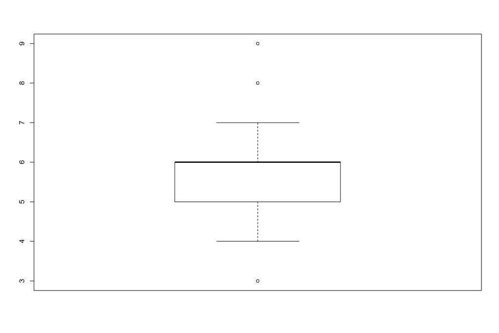

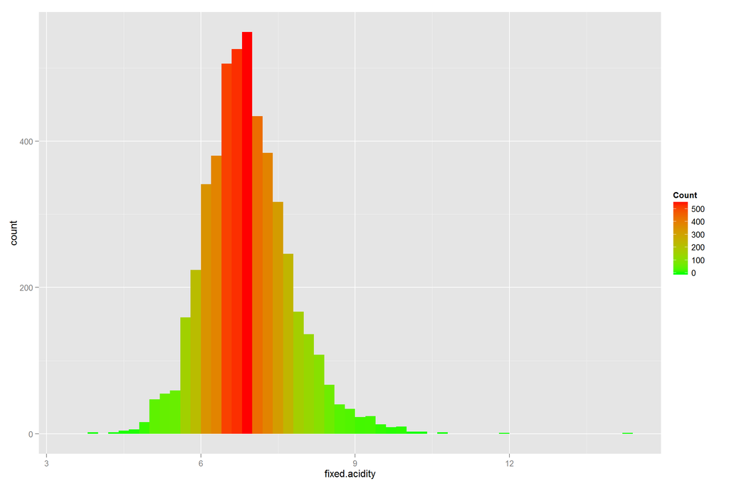

More Clear boxplot.

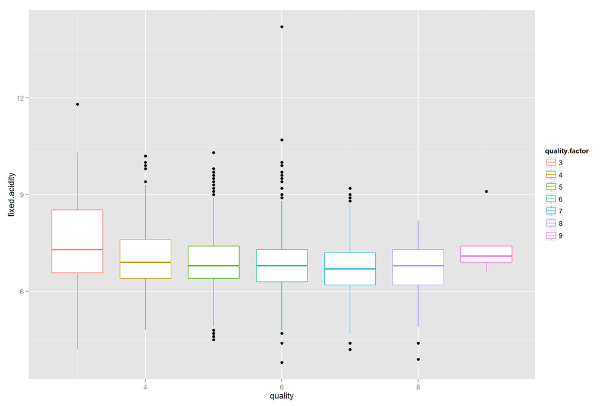

Histogram of wine quality:

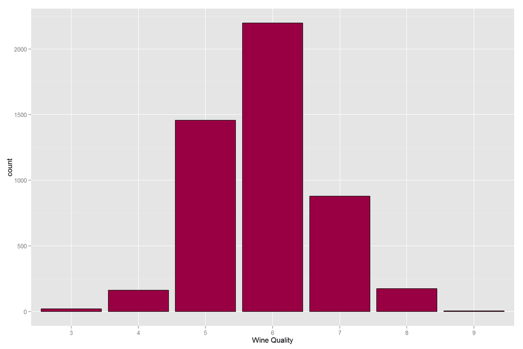

For most of the wine in our dataset, quality falls between 5 and 7 which is a range for good wines. There are couple of exceptions as excellent wine(8 or above), and poor (4 or below)

Wine Acidity

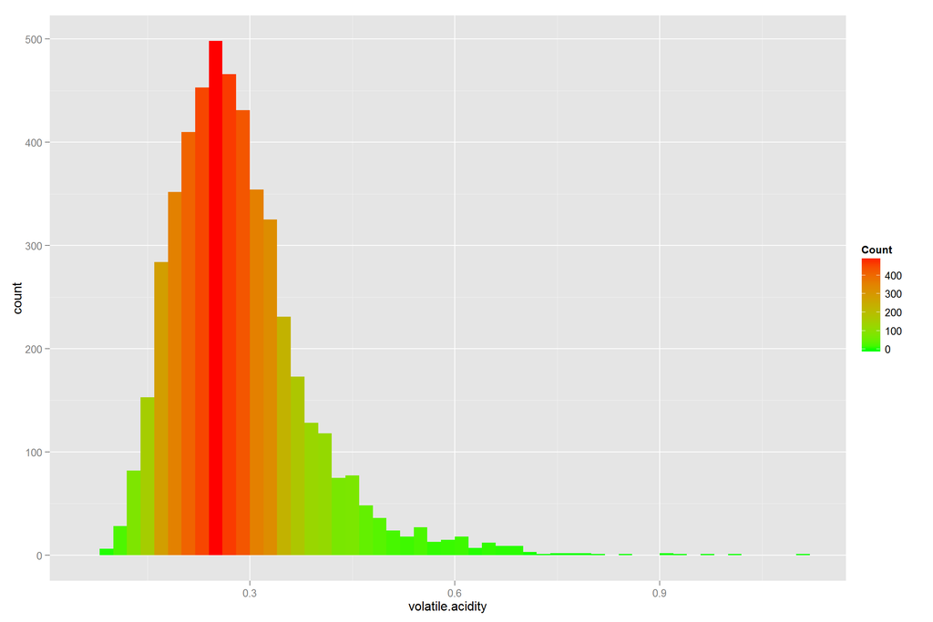

Look at relationship with quality.

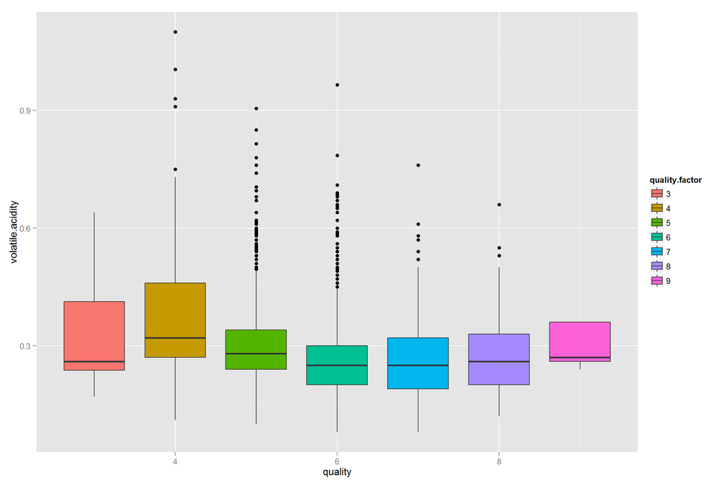

There is no visible separation based on this plot. So I’m going to combine acidity variables with quality.

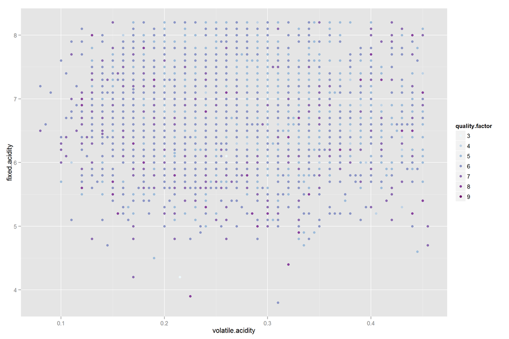

Unfortunately, no visual understandable separation using this two features. Go forward to next feature from white wine dataset.

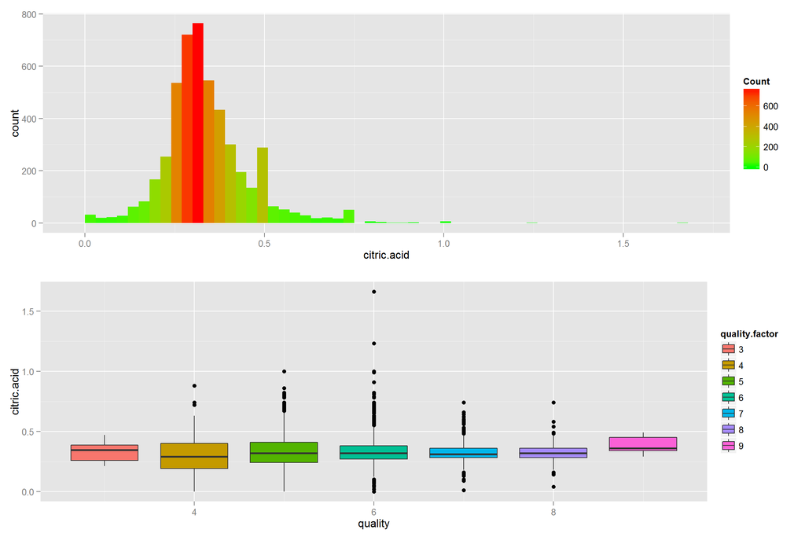

Plots above don’t show any clear patterns. But we can note that there are much more citric.acid outliers with quality equal 6. Look at residual.sugar variable. In histogram below we can observe unusual peaks with count near 600~800, but at the same time boxplots gives us no additional information about patterns.

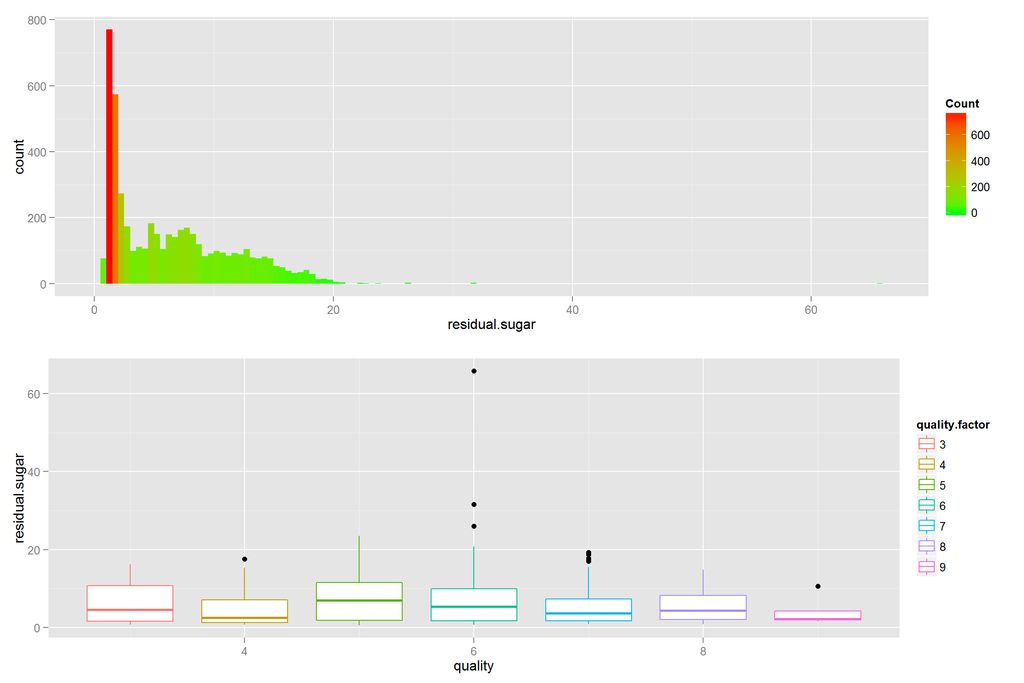

Combining residual.sugar and citric.acid variables to determine some linear separation.

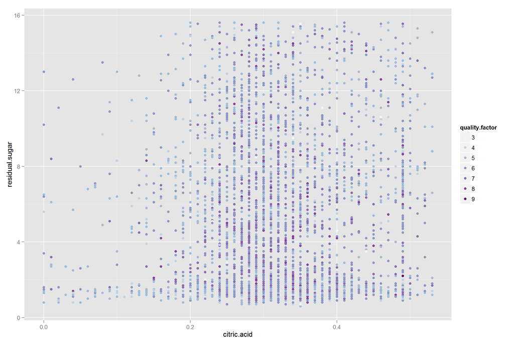

No clearn patterns, but we can observe quite nice relationship between this variables with different modes(citric.acid - centered, residual.sugar near zero) and plot looks nice. Move to next variable - chlorides.

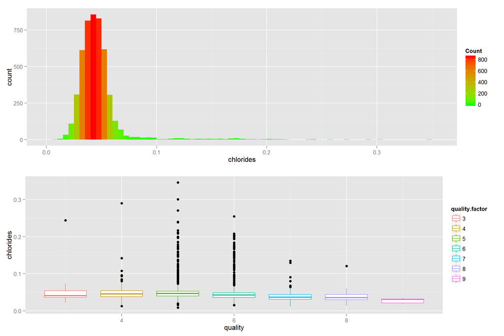

More meaningful variable. Easily can see to many outliers in wine with quality 5 and 6. But medians is still near the same value for all wine quality.

Exploring together free silfur and total sulfur dioxides. From plots below there is no signifficant information for patterns discovery except few outliers for wine with quality 3.

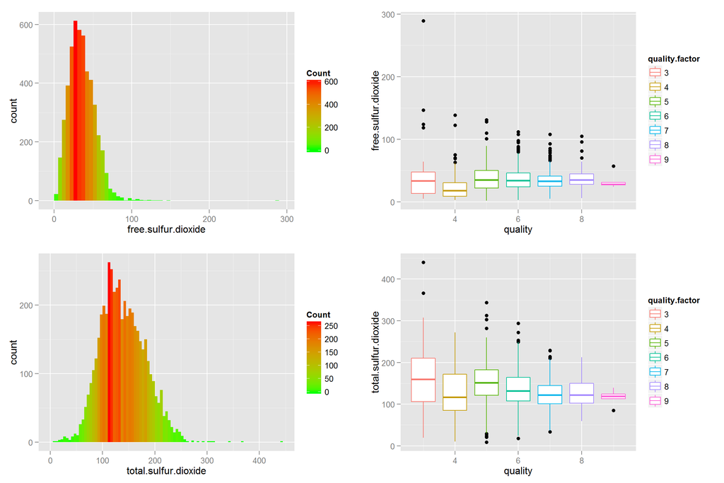

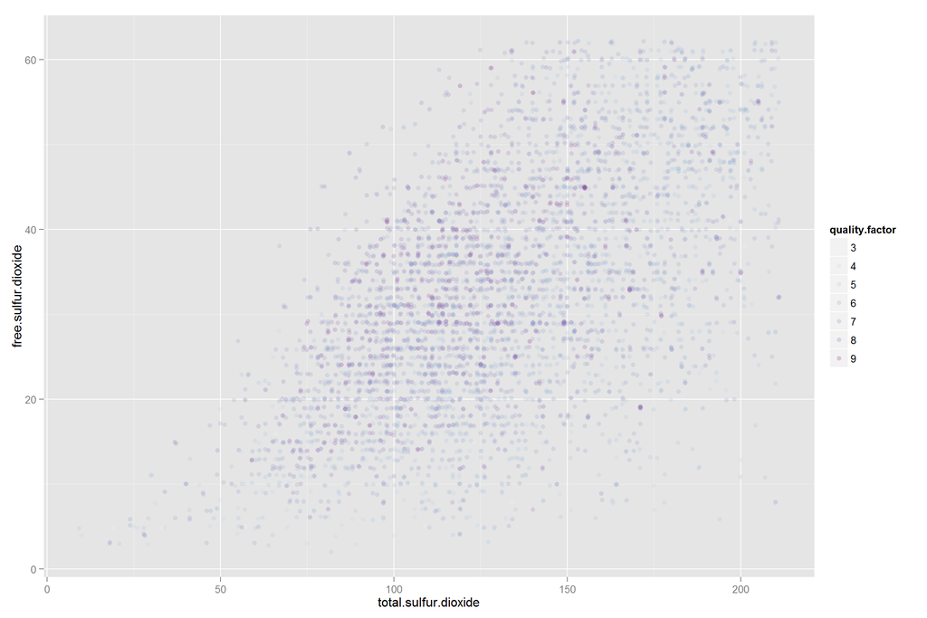

Unfortunately no meaningful separation yet, but insteresting plot above is one of the examples of regression to the mean i think. Going to next variables density and Ph. Density is too simillar for all kinds of wines and hard to investigate due to some outliers, so i decided to use 0.95 quantile to filter data.

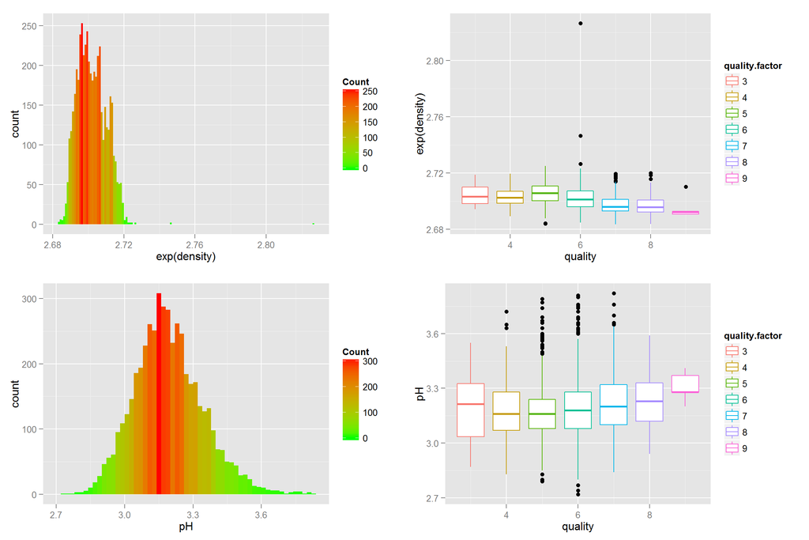

We can see some interesting trends from this plots, like with less density -> quality higher. The same is for pH, but in median thinking. Combine this two features to look at this data.

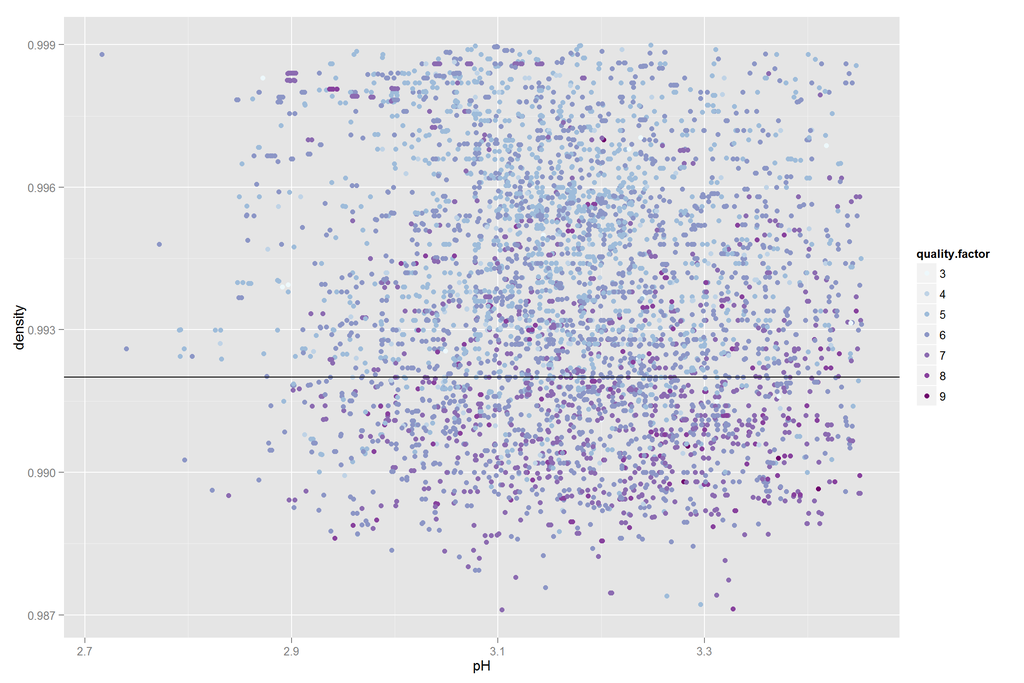

Look like under black line there is more chance that wine quality is high. In someway first result.

Okey. And the last two variables alcohol and sulphates.

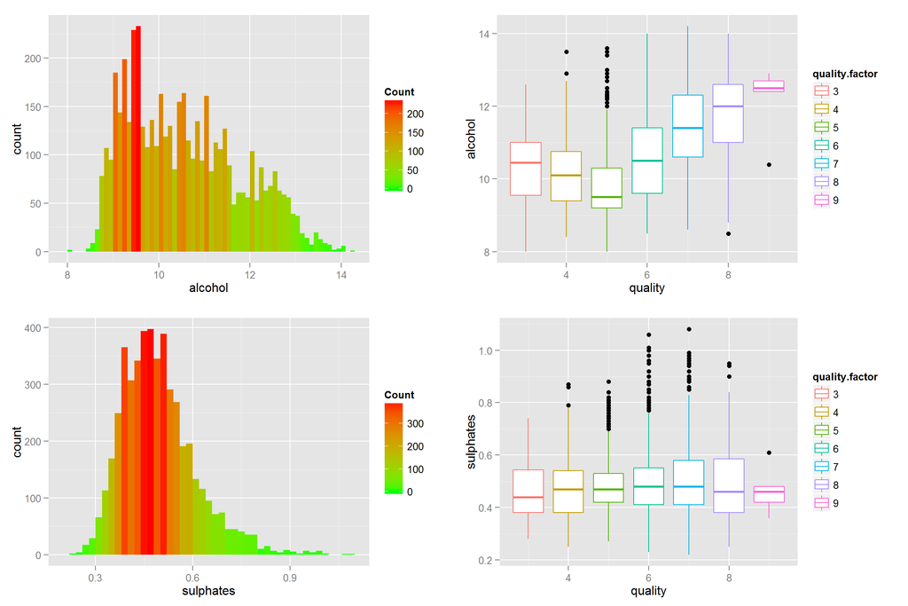

In median thinking more alcohol in wine implies higher quality, based on this plots, unfortunately sulphates is not so separable for different wine qualities. Combining isn’t suitable due to low variability of sulphates variables.

### Correlation exploration

following diagrams give us a good sense of the distribution and correlation among input variables in our dataset:

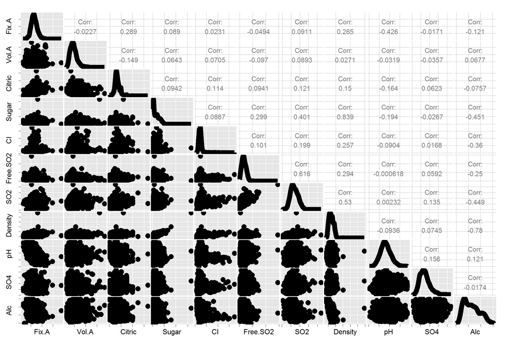

To avoid multicollinearity in model building using regressions, we have to be aware of strong correlations among input variables.

#### Analyzing correlation between Quality and input variables

We use Spearman’s rho statistic to estimate a rank-based measure of association. Correlations falls between -1 and 1. 0 suggests there is no association between the two variables while numbers close to -1 or 1 suggests strong negative and positive associations accordingly.

```
##                              [,1]
## fixed.acidity        -0.113662831
## volatile.acidity     -0.194722969
## citric.acid          -0.009209091
## residual.sugar       -0.097576829
## chlorides            -0.209934411
## free.sulfur.dioxide   0.008158067
## total.sulfur.dioxide -0.174737218
## density              -0.307123313
## pH                    0.099427246
## sulphates             0.053677877
## alcohol               0.435574715
```

The above results shows that wine quality has positive correlation with alcohol and negative correlation with chlorides and density

We will do more analysis in relationship between wine quality and its properties more to be able to predict the quality of wine.

#### Role of pH and Alcohol in Quality of the wine

What is impact of Alcohol and pH in wine quality?

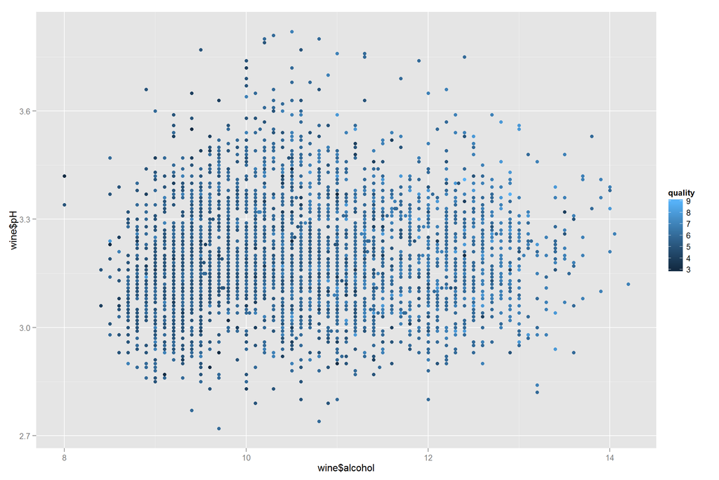

It is difficult to find specific pattern in this figure since quality has a wide range. I will limit the quality of wine into three categories of Poor, Good and Great to be able to differntiate patterns in each category.

below is how the quality of wines is distributed based on the above rating :

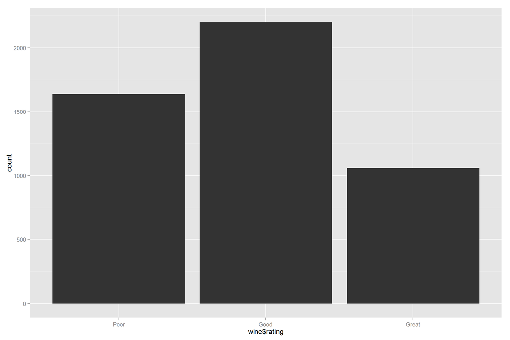

Now again we plot the two features of pH and Alcohol but this time use the new rating to see a pattern between quality and these two features:

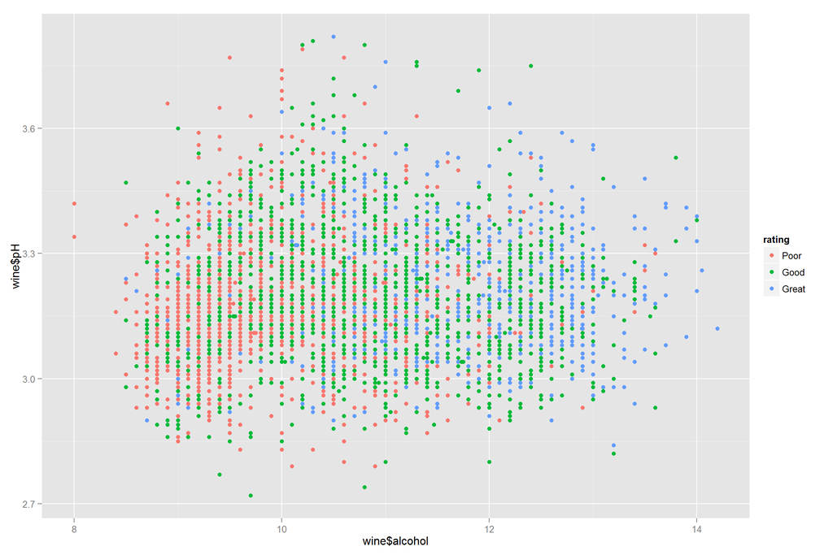

According to the above scatter plot, there seems to be a relationship between alcohol percentage and rating of the wine. most of great wines are in the right side of the plot. More specifically, if the alcohol percentage is above 11% there seems to be a good chance that we will have a good or great wine (great wine has rating 7 or above, good ones has quality above 5). If it is more than 12% the chance is even higher.

However, to see the relationship better, in below chart we will use only Alcohol and Quality to find out if there is actually a relationship between the two.

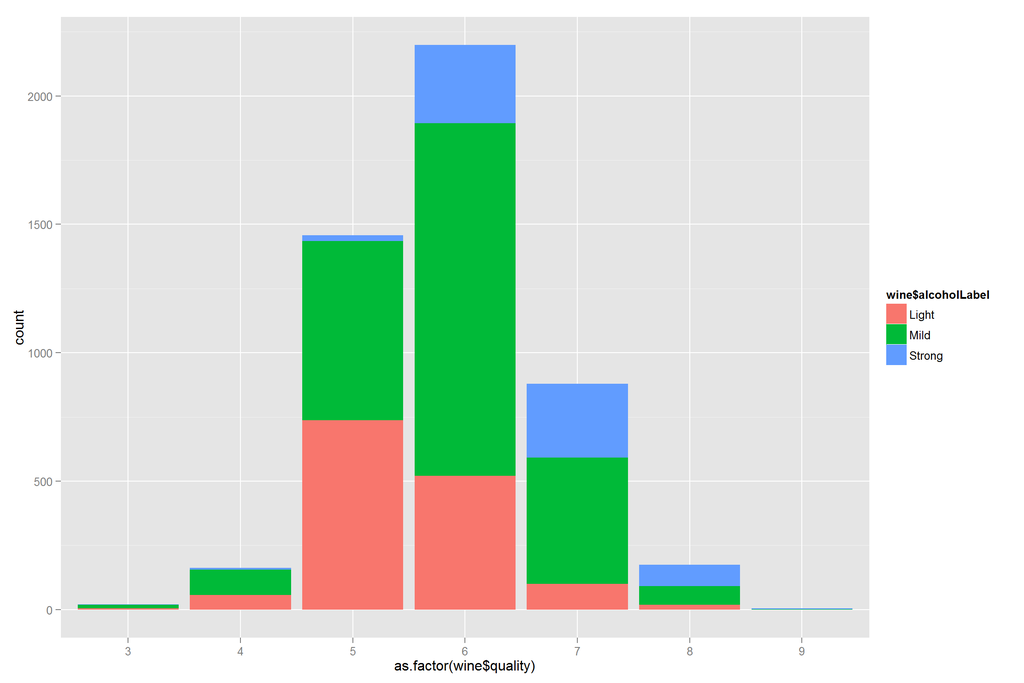

As you can see in the above stacked bar, for the higher quality wines there is more chance that the wine has higher alcohol percentage.

Here is how we have categorized the alchol percentage:

- “Light”: Alcohol percentage below 10%
- “Mild” : Alcohol percentage higher than 10% but below 12%
- “Strong”: Alcohol percentage higher than 12%

#### Relationship between density and alcohol percentage

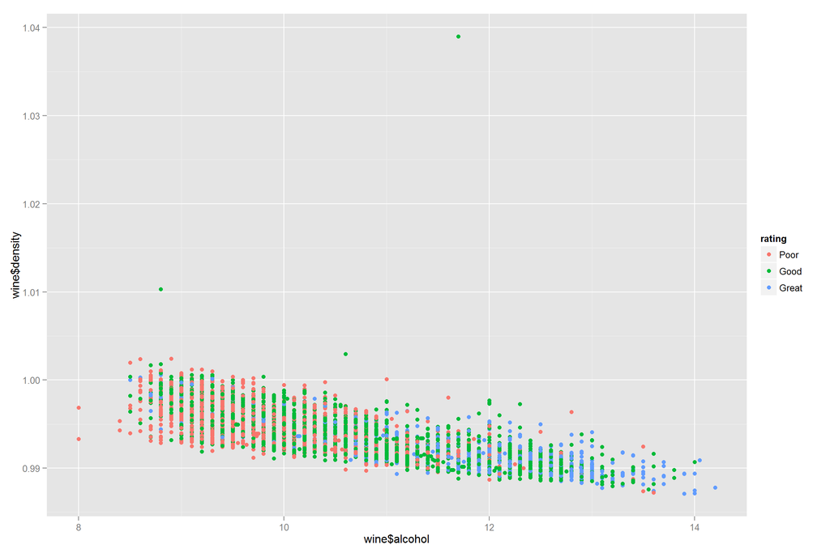

There seems to be a correlation between density and alcohol percentage. Less dense, more alcohol. Also, great wines tend to be less dense.

#### Relationship between Quality and Chlorides

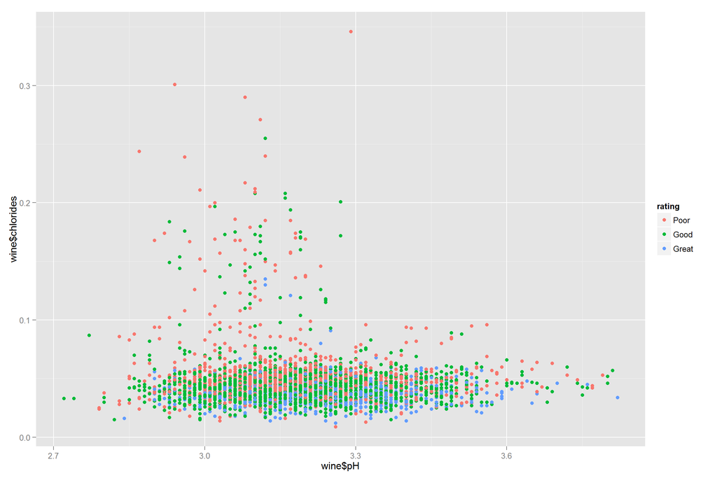

Wines with better quality tend to have less chlorides. If the chlorides level is higher than 0.050, there is a good chance the wine has worse rating.

Let’s look at correlations between all variables and numeric analogue of quality.

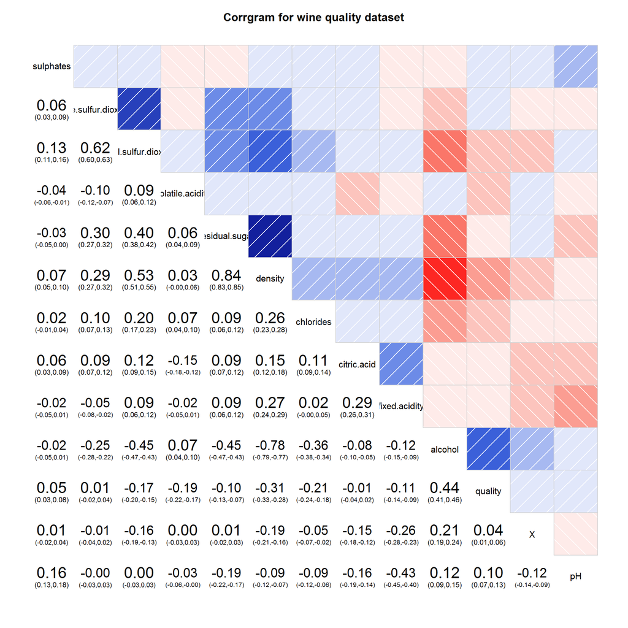

Notes:

1. Highest correlation for quality with alcohol 0.44. I’ve note this before during exploration.
2. Highest correaltion between residual sugar and density 0.84.
3. A lot of correlations are meaningless due to confidence interval.
4. Lowest correlation for quality with density -0.31.
5. Lowest correlation between alcohol and density -0.78 .

From corrgram we can conclude next important variables for quality prediction (decision is made using confidence intervals):

1. pH (0.1)
2. alcohol (0.44)
3. fixed.acidity (-0.11)
4. volatile.acidity (-0.19)
5. chlorides (-0.21)
6. density (-0.31)
7. residual.sugar (-0.10)
8. total.sulfur.dioxide (-0.17)

### Multivariate plots for understanding patterns between features

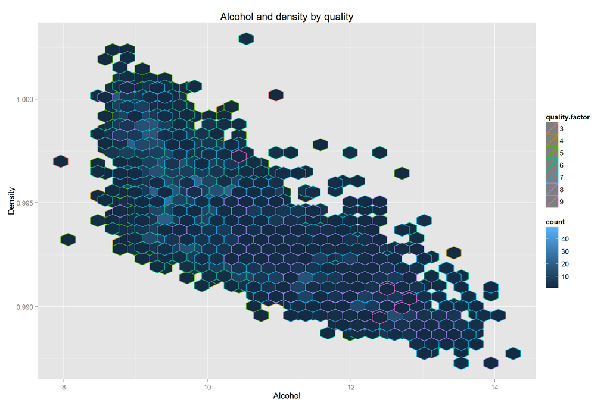

### Predicting Wine Quality

Using the insights that we have now about our data, we will try to predict the quality of wine.

I will use three levels rating (“Poor”, “Good”, “Great”) as an output variable.

```
##
##  Poor  Good Great
##  1640  2198  1060
```

This is the baseline for accuracy of our model:

2198/ (1640 + 2198 + 1060) = 0.44

#### Multinomial Logistic Regression

WE will use multinomial logistic regression to classify ratings of wine.

In our earlier analysis we found that there is a strong relationship between wine quality and its alcohol percentage. Lets predict the rating of wine just based on its alcohol percentage.

Here is the prediction:

```
##        pred_mglm
##         Poor Good Great
##   Poor   918  696    26
##   Good   631 1336   231
##   Great  128  619   313
```

##### AIC - Akaike information criterion

Accuracy = (918+1336+313)/total = 0.52

AIC: 9211.864

We can see that just by using one variable, we could improve the baseline accuracy significantly.

In our next model we predict the rating of a wine based on its alcohol percentage, chlorides and volitile acidity:

Here is the prediction:

```
##        pred_mglm
##         Poor Good Great
##   Poor   956  660    24
##   Good   526 1409   263
##   Great   80  665   315
```

AIC: 8838.35

As expected the accuracy imporved significantly.

Last step is just to use full model (all inputs) to predict quality of wine.

Prediction:

```
##        pred_mglm
##         Poor Good Great
##   Poor  1640    0     0
##   Good     0 2198     0
##   Great    0    0  1060
```

AIC: 8602.719

Also we can compare the Akaike information criterion (AIC) for the three models and we can see that from the first model to the second one the AIC improved significantly but from the second model to the full model it improved slightly.

#### Decision Tree

Using Decision Trees to predict Alcohol Quality:

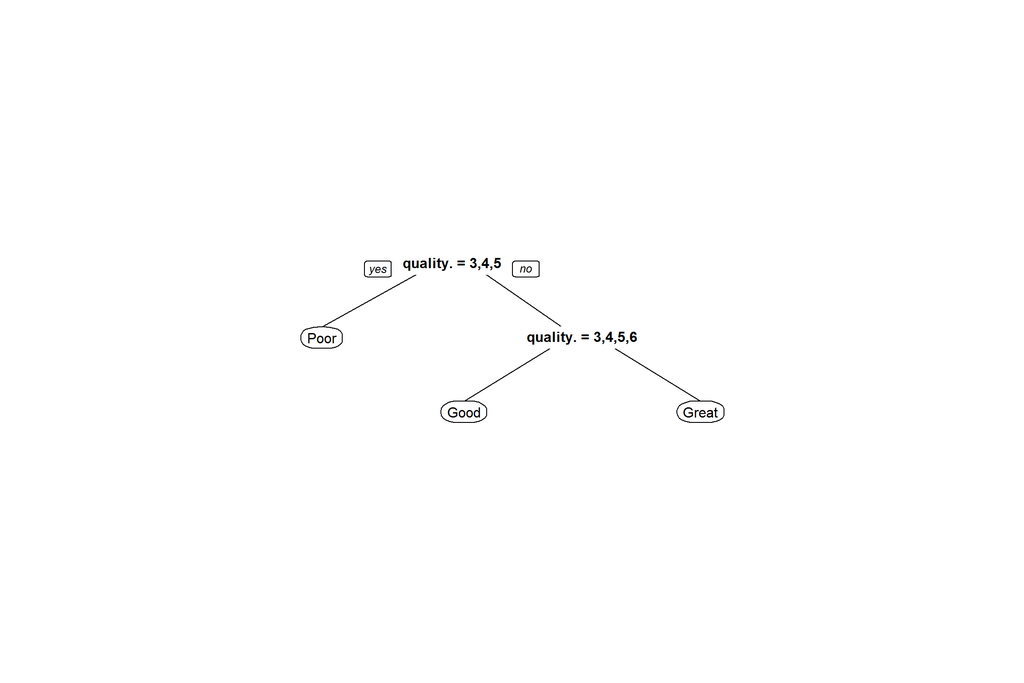

Here is the confusion matrix based on this model:

```
##        pred_CART
##         Poor Good Great
##   Poor  1640    0     0
##   Good     0 2198     0
##   Great    0    0  1060
```

[figure not shown]

Now let’s see the confusion matrix:

```
##        pred_CART
##         Poor Good Great
##   Poor  1640    0     0
##   Good     0 2198     0
##   Great    0    0  1060
```

This is the best accuracy that we could achieve so far

#### Random Forest

As out last model we will use random forest classification to predict quality of wine.

Now let’s see the confusion matrix:

```
##        pred_RF
##         Poor Good Great
##   Poor  1640    0     0
##   Good     0 2198     0
##   Great    0    0  1060
```

## Final Plots and Summary

#### Histogram of Wine Quality:

Firstly, in below plot I will display histogram of wine quality to see how quality is distributed in our dataset.

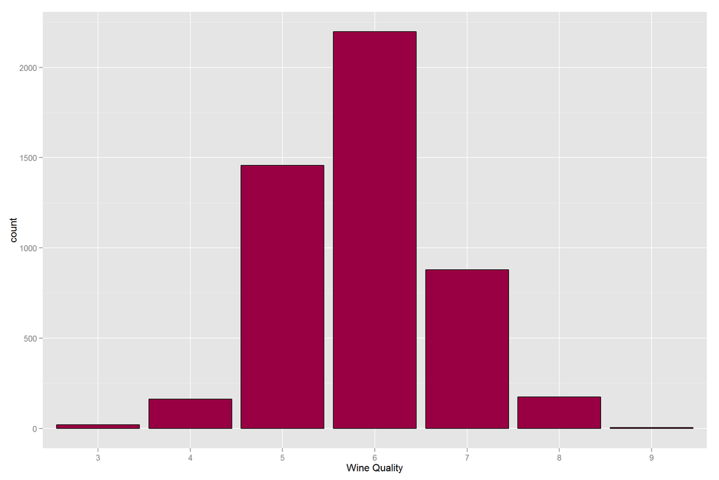

The quality rating with highest number is 6. Also we can see that most of wines in our dataset is rated between 5 and 7.

#### Is there any relationship between Alcohol percentage and Wine Density? Do these features impact wine rating?

I will show a scatter plot of data using Alcohol percentage and Wine density as x and y axis respectively. Also to understand contribution of the two in wine quality, another dimention (color) is added which is wine rating.

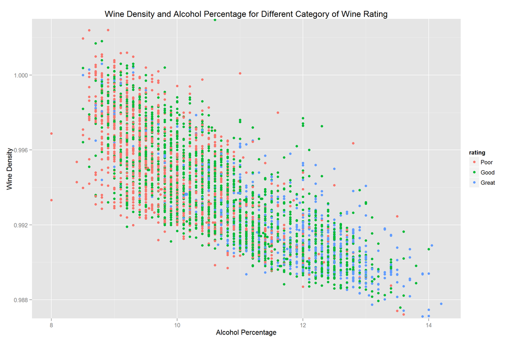

Above figure is also interesting and it has very useful information about our dataset. As you can see in the scatterplot there is a relationship between *Alcohol Pecentage* and *Wine Density*. The higher the alcohol percentage, the lower is the density. Also in previous section, we found out that the correlation between the two is *-0.78* which relatively suggests a strong negative relationship.

Another useful piece of information in this plot is the relationship between alcholo percentage and wine rating. While left side of the plot consists of red points (Poor Wines), right hand side of the plot mostly consist of Green and Blue points (Good and Great wines). In other words, stronger wines (in trems of alchols) tend to be rated higher. (This will be investigated even more in the next plot)

#### Histogram of Alcohol Percentage and Wine Quality:

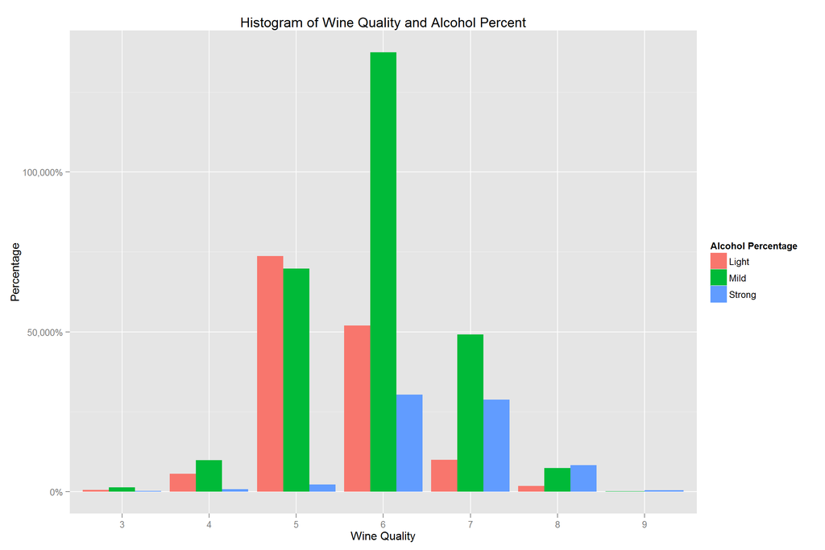

This is such an interesting plot as it conveys a lot. It provides information about the quality of wine, alcohol percentage and also relationship between the two.

In previous section, we mentioned that correlation between Wine quality and its alcohol percentage is **0.435**.

## Reflection

The white wine quality data set contains information on almost 4898 wines, their chemical properties and wine quality from best experts (i believe).

## Future Analysis

In retrospective, there are various challenges, success, and data enrichment for future work. There is defenitely a great room to do further analysis and come with better models. Below is some ideas to make this study even better:

- In this project the models were evaluated using the same data that was trained. This is not recommended. Performance should be reported based on the seperate set of data. Therefore, for future studies I recommend to split data into train and test and then do the analysis.
- In the last model, we used Random Forest Classification which is very prone to over-fitting. Using seperate train and test data would help to report right number for performance. Also we can use Cross Validation to adjust the parameters of the classification method.
- The only crriteria we used for perfomance was accuracy. While it is indicative of our model’s performance, it is not exhaustive yet. A better idea would be to look at the prediction and see how was the prediction are from actual data. For example if a Great wine is predicted as Good, it is more tolerable than if it is predicted as Poor. Therefore we can use weighted accuracy measures to report on performance.
- This is such a rich dataset and many relationship and correlations can be extracted from data and in this project we investigated very obvious relationships between wine qualities and its properties.

## References

1. https://s3.amazonaws.com/udacity-hosted-downloads/ud651/wineQualityInfo.txt
2. https://onlinecourses.science.psu.edu/stat857/node/223
3. R Graphics Cookbook - Winston Chang
4. https://flowingdata.com/ - Learning about Visualization as a paid Member
5. https://www.datacamp.com/- Learning more about R Language
6. Building Interactive Graphs with ggplot2 and Shiny - PACKT - Video
7. ggplot2 Essentials - Donato Teutonico
8. Data Science Specializations - Coursera - Currently taking it.
9. Udemy - Applied Multivariate Analysis with R
10. Udemy - Multivariate Data Visualization with R